Retrieved from Kaggle: https://www.kaggle.com/datasets/uciml/breast-cancer-wisconsin-data?resource=download

# Breast Cancer Wisconsin Data Classification Project

## `About The Dataset (info from Kaggle's page)`

Features are computed from a digitized image of a fine needle aspirate (FNA) of a breast mass. They describe characteristics of the cell nuclei present in the image. n the 3-dimensional space is that described in: [K. P. Bennett and O. L. Mangasarian: "Robust Linear Programming Discrimination of Two Linearly Inseparable Sets", Optimization Methods and Software 1, 1992, 23-34].

This database is also available through the UW CS ftp server: ftp ftp.cs.wisc.edu cd math-prog/cpo-dataset/machine-learn/WDBC/

Also can be found on UCI Machine Learning Repository: https://archive.ics.uci.edu/ml/datasets/Breast+Cancer+Wisconsin+%28Diagnostic%29

FEATURES Information:

1. ID number
2. Diagnosis (M = malignant, B = benign) 3-32)

Ten real-valued features are computed for each cell nucleus:

3. radius (mean of distances from center to points on the perimeter)
4. texture (standard deviation of gray-scale values)
5. perimeter
6. area
7. smoothness (local variation in radius lengths)
8. compactness (perimeter^2 / area - 1.0)
9. concavity (severity of concave portions of the contour)
10. concave points (number of concave portions of the contour)
11. symmetry
12. fractal dimension ("coastline approximation" - 1)

The mean, standard error and "worst" or largest (mean of the three largest values) of these features were computed for each image, resulting in 30 features. For instance, field 3 is Mean Radius, field 13 is Radius SE, field 23 is Worst Radius.

`NOTE: FOR THIS PROJECT ONLY THE FIRST 12 COLUMNS WILL BE KEPT, THE "STANDARD_ERROR", AND "WORST" FEATURES WILL BE DROPPED.`

All feature values are recoded with four significant digits.

Missing attribute values: none

Class distribution: 357 benign, 212 malignant

## `Main objectives`

1. Do EDA (the data wrangling is done by default)
2. Transform/Standardize data (preprocessing)
3. Train 3 classification models
4. Finally, predict whether the cancer is benign or malignant

```python
import pandas as pd
```

```python
data = pd.read_csv("breast_cancer_data.csv",sep=",")
```

```python
data.head()
```

|  | id | diagnosis | radius_mean | texture_mean | perimeter_mean | area_mean | smoothness_mean | compactness_mean | concavity_mean | concave points_mean | ... | texture_worst | perimeter_worst | area_worst | smoothness_worst | compactness_worst | concavity_worst | concave points_worst | symmetry_worst | fractal_dimension_worst | Unnamed: 32 |
| --- | --- | --- | --- | --- | --- | --- | --- | --- | --- | --- | --- | --- | --- | --- | --- | --- | --- | --- | --- | --- | --- |
| 0 | 842302 | M | 17.99 | 10.38 | 122.80 | 1001.0 | 0.11840 | 0.27760 | 0.3001 | 0.14710 | ... | 17.33 | 184.60 | 2019.0 | 0.1622 | 0.6656 | 0.7119 | 0.2654 | 0.4601 | 0.11890 | NaN |
| 1 | 842517 | M | 20.57 | 17.77 | 132.90 | 1326.0 | 0.08474 | 0.07864 | 0.0869 | 0.07017 | ... | 23.41 | 158.80 | 1956.0 | 0.1238 | 0.1866 | 0.2416 | 0.1860 | 0.2750 | 0.08902 | NaN |
| 2 | 84300903 | M | 19.69 | 21.25 | 130.00 | 1203.0 | 0.10960 | 0.15990 | 0.1974 | 0.12790 | ... | 25.53 | 152.50 | 1709.0 | 0.1444 | 0.4245 | 0.4504 | 0.2430 | 0.3613 | 0.08758 | NaN |
| 3 | 84348301 | M | 11.42 | 20.38 | 77.58 | 386.1 | 0.14250 | 0.28390 | 0.2414 | 0.10520 | ... | 26.50 | 98.87 | 567.7 | 0.2098 | 0.8663 | 0.6869 | 0.2575 | 0.6638 | 0.17300 | NaN |
| 4 | 84358402 | M | 20.29 | 14.34 | 135.10 | 1297.0 | 0.10030 | 0.13280 | 0.1980 | 0.10430 | ... | 16.67 | 152.20 | 1575.0 | 0.1374 | 0.2050 | 0.4000 | 0.1625 | 0.2364 | 0.07678 | NaN |

5 rows × 33 columns

```python
data.duplicated().value_counts()
```

```
False    569
Name: count, dtype: int64
```

```python
data = data.iloc[:,1:12]
```

```python
data.info()
```

```
<class 'pandas.core.frame.DataFrame'>
RangeIndex: 569 entries, 0 to 568
Data columns (total 11 columns):
 #   Column                  Non-Null Count  Dtype
---  ------                  --------------  -----
 0   diagnosis               569 non-null    object
 1   radius_mean             569 non-null    float64
 2   texture_mean            569 non-null    float64
 3   perimeter_mean          569 non-null    float64
 4   area_mean               569 non-null    float64
 5   smoothness_mean         569 non-null    float64
 6   compactness_mean        569 non-null    float64
 7   concavity_mean          569 non-null    float64
 8   concave points_mean     569 non-null    float64
 9   symmetry_mean           569 non-null    float64
 10  fractal_dimension_mean  569 non-null    float64
dtypes: float64(10), object(1)
memory usage: 49.0+ KB
```

```python
data.diagnosis.value_counts(normalize=True)
```

```
diagnosis
B    0.627417
M    0.372583
Name: proportion, dtype: float64
```

```python
feature_names = [i for i in data.columns if i != "diagnosis"]
```

```python
display(data.iloc[:,1:].describe())
display(data.iloc[:,0].describe())
```

|  | radius_mean | texture_mean | perimeter_mean | area_mean | smoothness_mean | compactness_mean | concavity_mean | concave points_mean | symmetry_mean | fractal_dimension_mean |
| --- | --- | --- | --- | --- | --- | --- | --- | --- | --- | --- |
| count | 569.000000 | 569.000000 | 569.000000 | 569.000000 | 569.000000 | 569.000000 | 569.000000 | 569.000000 | 569.000000 | 569.000000 |
| mean | 14.127292 | 19.289649 | 91.969033 | 654.889104 | 0.096360 | 0.104341 | 0.088799 | 0.048919 | 0.181162 | 0.062798 |
| std | 3.524049 | 4.301036 | 24.298981 | 351.914129 | 0.014064 | 0.052813 | 0.079720 | 0.038803 | 0.027414 | 0.007060 |
| min | 6.981000 | 9.710000 | 43.790000 | 143.500000 | 0.052630 | 0.019380 | 0.000000 | 0.000000 | 0.106000 | 0.049960 |
| 25% | 11.700000 | 16.170000 | 75.170000 | 420.300000 | 0.086370 | 0.064920 | 0.029560 | 0.020310 | 0.161900 | 0.057700 |
| 50% | 13.370000 | 18.840000 | 86.240000 | 551.100000 | 0.095870 | 0.092630 | 0.061540 | 0.033500 | 0.179200 | 0.061540 |
| 75% | 15.780000 | 21.800000 | 104.100000 | 782.700000 | 0.105300 | 0.130400 | 0.130700 | 0.074000 | 0.195700 | 0.066120 |
| max | 28.110000 | 39.280000 | 188.500000 | 2501.000000 | 0.163400 | 0.345400 | 0.426800 | 0.201200 | 0.304000 | 0.097440 |

```
count     569
unique      2
top         B
freq      357
Name: diagnosis, dtype: object
```

#### Label Encoding the "diagnosis" Target (Benign = 0, Malicious = 1)

```python
from sklearn.preprocessing import LabelEncoder
le = LabelEncoder()
data.diagnosis = le.fit_transform(data.diagnosis)
le.classes_
```

```
array(['B', 'M'], dtype=object)
```

#### As seen below, there's a clear difference between the Benign and Malicious Classes

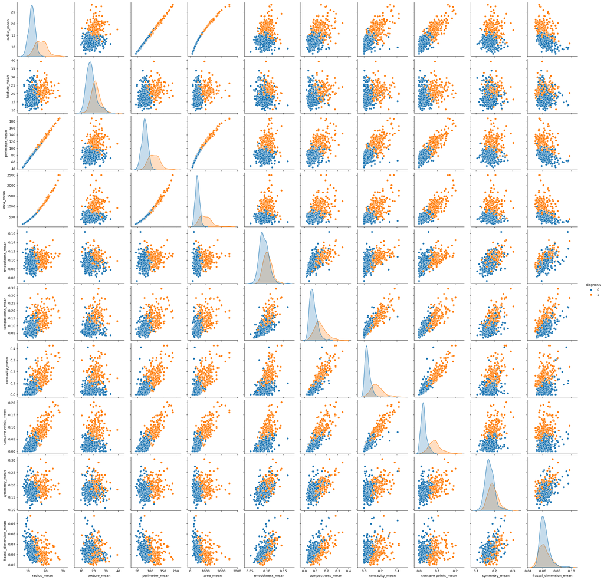

```python
import seaborn as sns
sns.pairplot(data, hue="diagnosis")
```

```python
skew_dict = dict()
for col in feature_names:
    skew_dict[col] = data[col].skew()

skew_df = pd.DataFrame(skew_dict,index=[0]).T.sort_values(by=0,ascending=False).rename(columns={0:'skew'})
```

```python
log1p_transform_columns = skew_df.query('skew > 0.7').index.to_list()
```

```python
X = data.loc[:, data.columns != 'diagnosis']
y = data[['diagnosis']]
```

```python
import numpy as np
for feat in log1p_transform_columns:
    X[feat] = np.log1p(X[feat])
```

```python
new_skew_list = list()
for col in X:
    new_skew_list.append(X[col].skew())

s1 = pd.Series(new_skew_list, name="log skew", index=[col for col in X])
```

#### Before and After of the Features Dataset (X) Log Transform to reduce skewness

```python
result = pd.concat([skew_df, s1], axis=1)
display(result)
```

|  | skew | log skew |
| --- | --- | --- |
| area_mean | 1.645732 | 0.287328 |
| concavity_mean | 1.401180 | 1.206982 |
| fractal_dimension_mean | 1.304489 | 1.272294 |
| compactness_mean | 1.190123 | 1.043195 |
| concave points_mean | 1.171180 | 1.083180 |
| perimeter_mean | 0.990650 | 0.328800 |
| radius_mean | 0.942380 | 0.348744 |
| symmetry_mean | 0.725609 | 0.632718 |
| texture_mean | 0.650450 | 0.650450 |
| smoothness_mean | 0.456324 | 0.456324 |

```python
from sklearn.model_selection import train_test_split
from sklearn.preprocessing import StandardScaler
```

```python
X_train,X_test,y_train,y_test = train_test_split(X, y, stratify=y, random_state=123, test_size=0.2)
display(y_train.value_counts(normalize=True))
display(y_test.value_counts(normalize=True))
```

```
diagnosis
0            0.626374
1            0.373626
Name: proportion, dtype: float64
```

```
diagnosis
0            0.631579
1            0.368421
Name: proportion, dtype: float64
```

#### Standard Scaling the X train/test data

```python
ss = StandardScaler()
X_train_scaled = ss.fit_transform(X_train)
X_test_scaled = ss.transform(X_test)
```

```python
X_train_scaled_df = pd.DataFrame(X_train_scaled, columns=X_train.columns, index=X_train.index)
X_test_scaled_df = pd.DataFrame(X_test_scaled, columns=X_test.columns, index=X_test.index)
```

## `Variations of classifier models`

```python
from sklearn.ensemble import RandomForestClassifier
from sklearn.inspection import permutation_importance, PartialDependenceDisplay
from sklearn.model_selection import GridSearchCV
import matplotlib.pyplot as plt
```

### Random Forest Classifier with Feature Importance and Partial Dependance Display

```python
RFClass = RandomForestClassifier(random_state = 123,bootstrap=True)
```

```python
param_dict = {"max_depth":[4,7,10],"max_features":[2,3,4],"n_estimators":[50,75,100]}
```

```python
search = GridSearchCV(estimator=RFClass,param_grid=param_dict,cv=3,n_jobs=2,verbose=1,scoring=["f1","roc_auc"],refit="f1")
search.fit(X_train_scaled_df,y_train.values.ravel())
```

```
Fitting 3 folds for each of 27 candidates, totalling 81 fits
```

```
GridSearchCV(cv=3, estimator=RandomForestClassifier(random_state=123), n_jobs=2,
             param_grid={'max_depth': [4, 7, 10], 'max_features': [2, 3, 4],
                         'n_estimators': [50, 75, 100]},
             refit='f1', scoring=['f1', 'roc_auc'], verbose=1)
```

```python
results = search.cv_results_
```

```python
pd.DataFrame(search.cv_results_).sort_values(by=["mean_test_f1","mean_test_roc_auc"],ascending=False).head()
```

|  | mean_fit_time | std_fit_time | mean_score_time | std_score_time | param_max_depth | param_max_features | param_n_estimators | params | split0_test_f1 | split1_test_f1 | split2_test_f1 | mean_test_f1 | std_test_f1 | rank_test_f1 | split0_test_roc_auc | split1_test_roc_auc | split2_test_roc_auc | mean_test_roc_auc | std_test_roc_auc | rank_test_roc_auc |
| --- | --- | --- | --- | --- | --- | --- | --- | --- | --- | --- | --- | --- | --- | --- | --- | --- | --- | --- | --- | --- |
| 11 | 0.123283 | 0.006261 | 0.013914 | 0.000617 | 7 | 2 | 100 | {'max_depth': 7, 'max_features': 2, 'n_estimat... | 0.895238 | 0.963636 | 0.941176 | 0.933350 | 0.028467 | 1 | 0.978578 | 0.986150 | 0.990132 | 0.984953 | 0.004792 | 3 |
| 9 | 0.061993 | 0.002357 | 0.009164 | 0.000641 | 7 | 2 | 50 | {'max_depth': 7, 'max_features': 2, 'n_estimat... | 0.895238 | 0.963636 | 0.941176 | 0.933350 | 0.028467 | 1 | 0.970175 | 0.985503 | 0.991917 | 0.982532 | 0.009121 | 14 |
| 17 | 0.136865 | 0.002228 | 0.012790 | 0.001035 | 7 | 4 | 100 | {'max_depth': 7, 'max_features': 4, 'n_estimat... | 0.893204 | 0.954955 | 0.941176 | 0.929778 | 0.026467 | 3 | 0.968329 | 0.983195 | 0.989474 | 0.980332 | 0.008867 | 22 |
| 26 | 0.230737 | 0.040338 | 0.027584 | 0.017658 | 10 | 4 | 100 | {'max_depth': 10, 'max_features': 4, 'n_estima... | 0.893204 | 0.954955 | 0.941176 | 0.929778 | 0.026467 | 3 | 0.968052 | 0.983564 | 0.989380 | 0.980332 | 0.009002 | 23 |
| 25 | 0.127741 | 0.018562 | 0.015885 | 0.003733 | 10 | 4 | 75 | {'max_depth': 10, 'max_features': 4, 'n_estima... | 0.893204 | 0.954955 | 0.941176 | 0.929778 | 0.026467 | 3 | 0.962512 | 0.982918 | 0.990226 | 0.978552 | 0.011728 | 24 |

```python
RF_best = search.best_estimator_
RF_best.get_params
```

```
<bound method BaseEstimator.get_params of RandomForestClassifier(max_depth=7, max_features=2, n_estimators=50,
                       random_state=123)>
```

```python
feature_importances = permutation_importance(estimator=RF_best, X = X_train_scaled_df, y = y_train, n_repeats=5, random_state=123, n_jobs=2)
```

```python
def visualize_feature_importance(importance_array):
    # Sort the array based on mean value
    sorted_idx = importance_array.importances_mean.argsort()
    fig, ax = plt.subplots()
    fig.set_figwidth(14)
    fig.set_figheight(8)
    fig.tight_layout()
    ax.boxplot(importance_array.importances[sorted_idx].T,
               vert=False, labels=X_train_scaled_df.columns[sorted_idx])
    ax.set_title("Permutation Importances (train set)")
    plt.show()
```

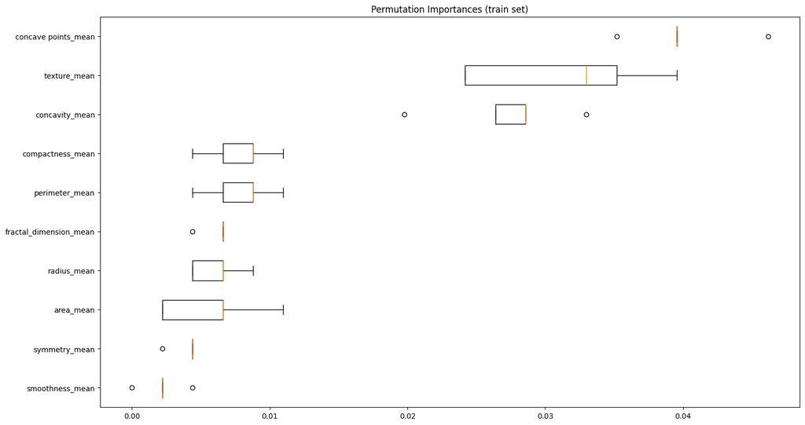

```python
visualize_feature_importance(feature_importances)
```

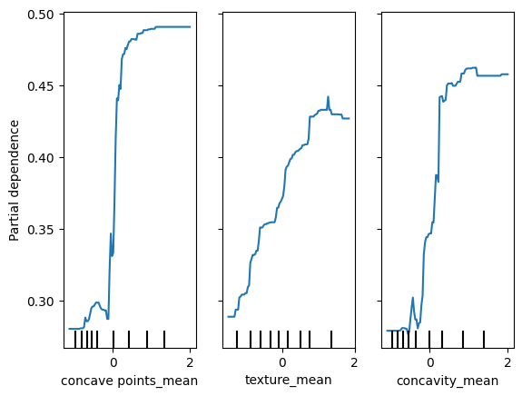

```python
important_features = ['concave points_mean', 'texture_mean', 'concavity_mean']

display = PartialDependenceDisplay.from_estimator(
    estimator=RF_best,
    X=X_train_scaled_df,
    features=important_features,
    random_state=123
)
```

##### These plots suggest that tumors with more concave points, higher concavity, and rougher textures are more likely to be classified as malignant. This aligns with medical knowledge, as malignant tumors often have more irregular shapes and textures compared to benign ones.

### Logistic Regression

```python
from sklearn.linear_model import LogisticRegressionCV

lr_cv = LogisticRegressionCV(random_state=123)
param_dict = {"Cs":[1,5,10], "penalty":["l1","l2"],"solver":["liblinear"], "max_iter":[1000]}
lr_search = GridSearchCV(estimator=lr_cv, param_grid=param_dict, cv=3,verbose=1,scoring=["f1","roc_auc"], refit="f1")
```

```python
lr_search.fit(X_train_scaled_df,y_train.values.ravel())
```

```
Fitting 3 folds for each of 6 candidates, totalling 18 fits
```

```
GridSearchCV(cv=3, estimator=LogisticRegressionCV(random_state=123),
             param_grid={'Cs': [1, 5, 10], 'max_iter': [1000],
                         'penalty': ['l1', 'l2'], 'solver': ['liblinear']},
             refit='f1', scoring=['f1', 'roc_auc'], verbose=1)
```

```python
pd.DataFrame(lr_search.cv_results_).sort_values(by=["mean_test_f1","mean_test_roc_auc"],ascending=False).head()
```

|  | mean_fit_time | std_fit_time | mean_score_time | std_score_time | param_Cs | param_max_iter | param_penalty | param_solver | params | split0_test_f1 | ... | split2_test_f1 | mean_test_f1 | std_test_f1 | rank_test_f1 | split0_test_roc_auc | split1_test_roc_auc | split2_test_roc_auc | mean_test_roc_auc | std_test_roc_auc | rank_test_roc_auc |
| --- | --- | --- | --- | --- | --- | --- | --- | --- | --- | --- | --- | --- | --- | --- | --- | --- | --- | --- | --- | --- | --- |
| 4 | 0.541086 | 0.035339 | 0.004183 | 0.000366 | 10 | 1000 | l1 | liblinear | {'Cs': 10, 'max_iter': 1000, 'penalty': 'l1', ... | 0.872727 | ... | 0.932203 | 0.905215 | 0.024590 | 1 | 0.973592 | 0.984488 | 0.993233 | 0.983771 | 0.008034 | 2 |
| 2 | 0.312323 | 0.065996 | 0.005073 | 0.000414 | 5 | 1000 | l1 | liblinear | {'Cs': 5, 'max_iter': 1000, 'penalty': 'l1', '... | 0.862385 | ... | 0.932203 | 0.901768 | 0.029197 | 2 | 0.974885 | 0.984857 | 0.992669 | 0.984137 | 0.007278 | 1 |
| 3 | 0.028406 | 0.001101 | 0.005033 | 0.000828 | 5 | 1000 | l2 | liblinear | {'Cs': 5, 'max_iter': 1000, 'penalty': 'l2', '... | 0.870370 | ... | 0.915254 | 0.898780 | 0.020174 | 3 | 0.978024 | 0.985596 | 0.986278 | 0.983299 | 0.003741 | 3 |
| 1 | 0.007721 | 0.000921 | 0.005061 | 0.000044 | 1 | 1000 | l2 | liblinear | {'Cs': 1, 'max_iter': 1000, 'penalty': 'l2', '... | 0.864865 | ... | 0.890756 | 0.892453 | 0.023250 | 4 | 0.975623 | 0.986150 | 0.984586 | 0.982120 | 0.004638 | 4 |
| 5 | 0.063782 | 0.003131 | 0.006318 | 0.000911 | 10 | 1000 | l2 | liblinear | {'Cs': 10, 'max_iter': 1000, 'penalty': 'l2', ... | 0.851852 | ... | 0.907563 | 0.890043 | 0.027036 | 5 | 0.973777 | 0.985226 | 0.985902 | 0.981635 | 0.005564 | 5 |

5 rows × 21 columns

```python
Log_best = lr_search.best_estimator_
Log_best.get_params
```

```
<bound method BaseEstimator.get_params of LogisticRegressionCV(max_iter=1000, penalty='l1', random_state=123,
                     solver='liblinear')>
```

### KNN with "distance" and "uniform" weights

```python
from sklearn.neighbors import KNeighborsClassifier
```

```python
params_grid = {'weights': ["distance","uniform"],"n_neighbors":[3,5]}
KNN_model = KNeighborsClassifier()
search = GridSearchCV(estimator = KNN_model,
                        param_grid = params_grid,
                        cv=3,
                        verbose=1,
                        scoring=["f1","roc_auc"],
                        refit="f1")
search.fit(X_train_scaled_df, y_train.values.ravel())
```

```
Fitting 3 folds for each of 4 candidates, totalling 12 fits
```

```
GridSearchCV(cv=3, estimator=KNeighborsClassifier(),
             param_grid={'n_neighbors': [3, 5],
                         'weights': ['distance', 'uniform']},
             refit='f1', scoring=['f1', 'roc_auc'], verbose=1)
```

```python
pd.DataFrame(search.cv_results_).sort_values(by=["mean_test_f1","mean_test_roc_auc"],ascending=False).head()
```

|  | mean_fit_time | std_fit_time | mean_score_time | std_score_time | param_n_neighbors | param_weights | params | split0_test_f1 | split1_test_f1 | split2_test_f1 | mean_test_f1 | std_test_f1 | rank_test_f1 | split0_test_roc_auc | split1_test_roc_auc | split2_test_roc_auc | mean_test_roc_auc | std_test_roc_auc | rank_test_roc_auc |
| --- | --- | --- | --- | --- | --- | --- | --- | --- | --- | --- | --- | --- | --- | --- | --- | --- | --- | --- | --- |
| 2 | 0.001334 | 0.000472 | 0.007005 | 0.000377 | 5 | distance | {'n_neighbors': 5, 'weights': 'distance'} | 0.886792 | 0.955752 | 0.923077 | 0.921874 | 0.028166 | 1 | 0.975162 | 0.993167 | 0.979699 | 0.982676 | 0.007646 | 1 |
| 3 | 0.001334 | 0.000470 | 0.014985 | 0.002932 | 5 | uniform | {'n_neighbors': 5, 'weights': 'uniform'} | 0.886792 | 0.955752 | 0.923077 | 0.921874 | 0.028166 | 1 | 0.974238 | 0.992059 | 0.980169 | 0.982155 | 0.007410 | 2 |
| 1 | 0.002015 | 0.000019 | 0.014676 | 0.002228 | 3 | uniform | {'n_neighbors': 3, 'weights': 'uniform'} | 0.880734 | 0.927273 | 0.900000 | 0.902669 | 0.019093 | 3 | 0.968144 | 0.989843 | 0.968703 | 0.975563 | 0.010100 | 3 |
| 0 | 0.002145 | 0.000997 | 0.008899 | 0.000842 | 3 | distance | {'n_neighbors': 3, 'weights': 'distance'} | 0.880734 | 0.927273 | 0.900000 | 0.902669 | 0.019093 | 3 | 0.966390 | 0.991320 | 0.967857 | 0.975189 | 0.011422 | 4 |

```python
KNN_best = search.best_estimator_
KNN_best.get_params
```

```
<bound method BaseEstimator.get_params of KNeighborsClassifier(weights='distance')>
```

#### Precision, Recall, F1, AUC, scores comparison

```python
from sklearn.metrics import classification_report, accuracy_score, precision_recall_fscore_support, confusion_matrix, ConfusionMatrixDisplay, precision_score, recall_score, roc_auc_score
```

```python
models_scores = {}
models_list = [RF_best,Log_best,KNN_best]
model_name = ["RandomForest","LogisticRegression", "KNNeigbors"]
```

```python
for model,label in zip(models_list,model_name):
    pred = model.predict(X_test_scaled_df)
    precision, recall, f1, support = precision_recall_fscore_support(y_test, pred, beta=1, average='binary')
    auc = roc_auc_score(y_test, pred)
    models_scores[label] = [precision, recall, f1,auc]
```

```python
scores_df = pd.DataFrame(models_scores)
```

```python
scores_df = scores_df.T
scores_df.columns = ["precision","recall","f1","auc"]
scores_df
```

|  | precision | recall | f1 | auc |
| --- | --- | --- | --- | --- |
| RandomForest | 0.854167 | 0.976190 | 0.911111 | 0.939484 |
| LogisticRegression | 0.930233 | 0.952381 | 0.941176 | 0.955357 |
| KNNeigbors | 0.909091 | 0.952381 | 0.930233 | 0.948413 |

## `Possible flaws in the model and a plan of action moving forward`

1. Overfitting the data: although the RandomForest is the least correlated model for the Tree Classifiers, it could be overfit if the number of leaves or the depth of the tree wasn't correctly tuned. Also, it might be a good idea to try a classifier different from KNN if down the road the dataset got larger.
2. The plan moving forward could be to investigate model performance across different patient demographics, compare performance across different models (e.g. SVM, neural networks).